# Hakalar2000_HomeworkOriginal

Me

September 16, 2019

This is code for [Homework 2](https://fuzzyatelin.github.io/bioanth-stats/homework-02.html), on week threee of AN597 associated with module 6 and 7.

> Every Saturday morning, at the same time, a primatologist goes and sits in the forest to listen for titi monkey calls, counting the number of calls they hear in a 2 hour window from 5am to 7am. Based on previous knowledge, she believes that the mean number of calls she will hear in that time is exactly 15. Let X represent the appropriate Poisson random variable of the number of calls heard in each monitoring session.
- problem 1
- problem 2
- problem 3
- problem 4
- problem 5
- problem 6

Mean = 15 Poisson Random Variable = X Time Frame: 2 hours

What is Poisson Distribution? * The experiment results in outcomes that can be classified as successes or failures. Calls or no calls, and how many calls. * The average number of successes (μ) that occurs in a specified region is known. We believe the average is 15 calls in a 2 hour period. * The probability that a success will occur is proportional to the size of the region. A region includes a time frame, in this case two hours. * The probability that a success will occur in an extremely small region is virtually zero. No calls in like 5 minutes but many calls in 2 hours.

A poison random variable is the number of successes that result from a Poisson experiment.

Question 1: What is the probability that she will hear more than 8 calls during any given session?

```r
#We will use the function ppois since it calculates the poisson probability for a variable that is not discrete. A discrete variable would be like exactly 8 calls, but we want to know the probablity of 8 calls and more.
#lambda is equal to the mean so lambda<-15
#q is equal to the number of success, in this case 8+
#lower.tail is equal to TRUE if you want the probability of less than a certain number and FALSE if you want probability of more than a certain number. Because we want to know the probability of the 8+ we want to use FALSE The default for this function is TRUE so we need to include lower in our function.

#ppois(q, lambda, lower.tail)
Probability<-ppois(q = 8, lambda = 15, lower.tail = FALSE)
Probability
```

```
## [1] 0.9625535
```

Question 2: What is the probability that she will hear no calls in a session?

```r
#Now we have a discrete value of 0 which means we want to use dpois.
#same variables as above except q = 0.
Probability<-dpois(0, lambda = 15)
Probability
```

```
## [1] 3.059023e-07
```

```r
#As you can see, there is very very low probability of our scinetist hearing nothing.
```

Question 3: What is the probability that she will hear exactly 3 calls in a session?

```r
#same as above but we replace 0 with 3
Probability<-dpois(3, lambda = 15)
Probability
```

```
## [1] 0.0001720701
```

```r
#Still low but more likely than 0 calls.
```

Question 4: Plot the relevant Poisson mass function over the values in range 0 ≤ x ≤ 30.

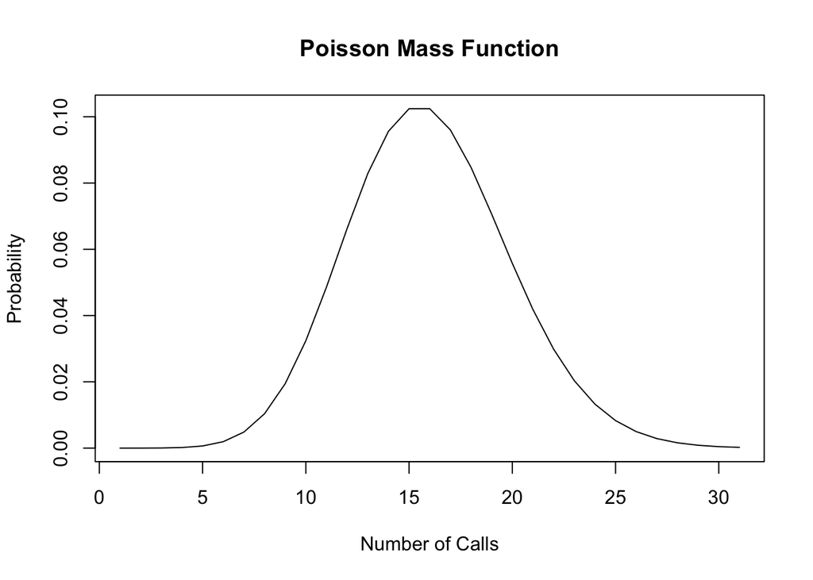

```r
#So from what I gather, the poisson mass function is a line. that shows the distribution of probabilities for a given function.
?plot
plot(dpois(x = 0:30, lambda = 15), type = "l", xlab = "Number of Calls", ylab = "Probability", main = "Poisson Mass Function")
```

```r
#We want to plot the discrete values for 0 to 30 for our poisson distribution which is why we used dpois. The type specifies the type of graph, in this case, l tells R to make a line graph. xlab, ylab, and main label the axises.
```

Question 5: Simulate 104 results from this distribution (i.e., 2 years of Saturday monitoring sessions).

```r
?rpois
#So my interweb searches have lead me to finding rpois(). So lets look for a little information about rpois().
rpois(104, lambda = 15)
```

```
##   [1] 20 19 12 13 13 16 21 17 17 20 15 16 16 17 20 14 15 23 11 18  8 16 18
##  [24] 14 16 17 22 15 14 11 18 21 21 16 14 16  8 15 19 14 15 17 14 18 14 14
##  [47] 25 17 17 17 15 16 20 10 15 15 23 13 18 14 14 21 18  7 18 12 13 14 14
##  [70] 21 16 13 19 13  9 14 16 14 17 18 10 18 23 12 14 20 10 17 17 16 15 25
##  [93] 12 13 13 12 16 26 15 17 16 19 12 16
```

```r
#That was rather easy! n = 104 (or the number of trials), and of course lambda still equals 15.
```

Question 6: Plot the simulated results using hist() and use xlim() to set the horizontal limits to be from 0 to 30. How does your histogram compare to the shape of the probability mass function you plotted above?

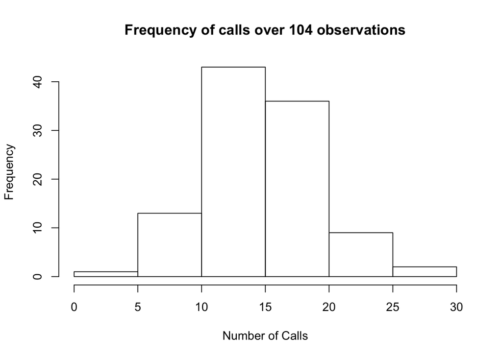

```r
?hist
x<-rpois(104, lambda = 15)
hist(x, xlim = c(0, 30), xlab = "Number of Calls", main = "Frequency of calls over 104 observations")
```

```r
#The hist() fucntion denotes a histogram. xlim sets the limits of the x axis, xlab lables the x axis and main labels the title of the histogram.
```

Five things I struggles with

> - Problem 4 through me off a bit, partly because I wasn’t sure if you wanted a line graph, a histogram, or a scatter plot. I went with line since thats what the internet said to do.
> - I had a bit of a struggle understanding what poisson is and what exactly its suppose to look like. I understand it predicts the probability of something but I am still confused by it.
> - For question 5 I got 104 results but they were not ordered in any way. I wasn’t sure if I should order them. Didn’t seem to important so I ignored it.
> - This homework seem to easy to me. I feel like I missed something.
> - How common is Poisson? And is creating random 104 results part of bootstrapping?